# Project 2: Global Shark Attacks

By: Brenden Ziemann  
DAT 301  
05/06/2022

## Introduction

The problem is where do shark attacks happen most in terms of countries and what can you tell about the attacks. Are there any patterns? Is there anything that stands out? Looking at this data there is many different results I can discuss and report. I have always been afraid of sharks growing up and I wanted to see how many shark attacks there are every year. If there has been an increase in shark attacks over the past century. Where do they happen most? Are most shark attacks fatal? There are so many questions I had and was curious to how scared should I be. I find it interesting to see this data and use it to map to countries and find out information I had no idea about until I started to look.

## Background

There are few shark attacks every year all across the world. But I feel it is a good idea to know when going on vacation about the countries that have a higher chance of attack or injury. It is good to know the information and interesting to know where sharks attack and the different facts that come with it. Knowing the details of the shark attacks is very interesting.

## Datasets

The data set I choose to use was global shark attacks for countries around the world. It is from the Shark Research Institute. It seems to be very reliable and has over 300 downloads of people using it. The data set shows all types of identification for shark attacks that range from the years 1500 to 2022. I choose to look at the years 1900 to 2022 to limit the amount of data. Also there isn't many from the years 1500 to 1900 which makes sense since it was harder to record back then. It uses the date, year, type, country, area(state/province), location(place), activity(what the person was doing),name, sex(M/F), age, injury(damage left by shark), fatal or not, time, and species(of shark) for each entry of an attack. The data set can be found here https://public.opendatasoft.com/explore/dataset/global-shark-attack/table/?disjunctive.country&disjunctive.area&disjunctive.activity

## Table of Contents:

### These are the topics for my project:

- Countries with Highest Number of Shark Attacks
- Countries with high fatal attacks
- Number of attacks per Year since 1900
- Ages of People that get Attacked
- Male vs Female getting Attacked
- Types of Shark Attacks

## Results

### Total Cases per Country

Many of the countries have very low number of cases between the years 1900 to 2022. These are the 10 countries with the highest number of shark attacks. USA has by far the highest amount of shark attacks in the world by far. Little less than 2 times more than the second place country of australia.

|  | Country | Attacks |
| --- | --- | --- |
| 0 | USA | 2284 |
| 1 | AUSTRALIA | 1278 |
| 2 | SOUTH AFRICA | 557 |
| 3 | PAPUA NEW GUINEA | 132 |
| 4 | BAHAMAS | 118 |
| 5 | BRAZIL | 115 |
| 6 | NEW ZEALAND | 110 |
| 7 | MEXICO | 87 |
| 8 | ITALY | 62 |
| 9 | NEW CALEDONIA | 60 |

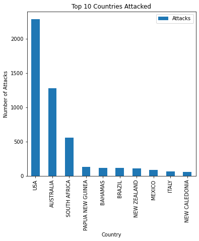

### Shark Attacks Every Year

This Graph explains the amount of shark attacks around the world from 1900 to 2022 for each year. There is a growth in the past 122 years. Looking at the scatter plot you can see an increase from 1900 to 2022. The amount of attacks per year has increased quite a bit. Especially from 2000 to 2020. There was a spike from 1960 to 1970.

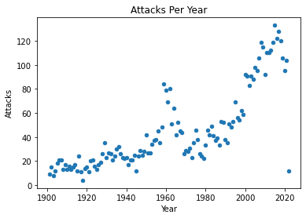

### Male to Female Comparison of Shark Attacks

Male to Female comparison between the Countries. You can see here that males have been more dominate to be attacked by sharks than females around the world. This map shows that where we live in the US there has been more female attacks but around the world males are more spread out across the countries to have more. The table shows the counts of attacks for females and males and as you can see Males get attacked a lot more than females.

|  | Type | Total |
| --- | --- | --- |
| 0 | M | 4392 |
| 1 | F | 659 |

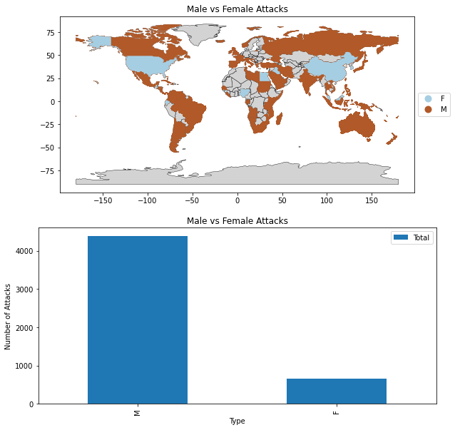

### Map of Ages that get Attacked most

From this graph we notice that a lot of the shark attacks are from younger aged people. Seen from the graph more people from age 16 to 28 get attacked the most. Histogram of frequency of ages that have been attacked.

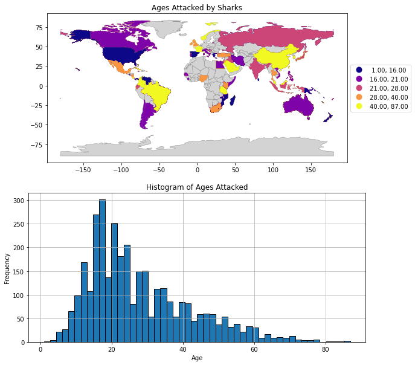

### Fatal Attacks For Countries

Many shark attacks aren't fatal but there are countries that have fatal attacks. Shown below is a world map of all the countries that have high fatal attacks along with the countries that have a lot less fatal attacks. This doesn't mean they are all fatal attacks in the countries but more fatal than the rest. The world plot shows that there a lot more fatal attacks in the southern part of the world than the northern. The bar plot below shows that more than 78% of shark attacks are non fatal.

|  | Type | Total |
| --- | --- | --- |
| 0 | N | 4109 |
| 1 | Y | 900 |

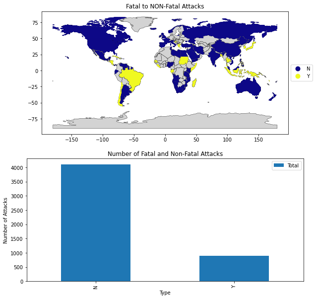

### Types of shark attacks around the world

Shark attacks around the world seem to be mostly unprovoked. There are countries however that have provoked shark attacks. These countries have more provoked shark attacks making the shark attack out of self defense or someone provking it in an agressive matter. There are two maps, one showing all the types and the other only shows Provoked vs Unprovoked attacks. Looking at the map not all but majority of the attacks are of that category for each country.

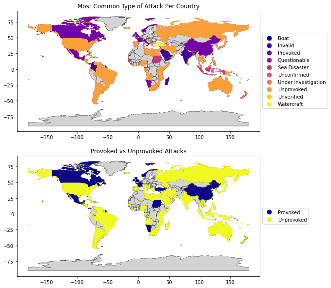